# Writing & Debugging Functions

Mar 3, 2026

## Today

- Syntax of defining functions
- Syntax of calling functions (you already know this)
- Function environments
- Debugging functions

## Elements of defining a function

- Function name
- Use of the function `function()`
- function arguments (0 to many)
  - specify input
  - how you tell the function to alter behavior
- the body
  - optional output
  - usually use `return()`

```r
fun_name<-function(arg1, arg2, etc.){ # Arguments common but not necessary
  new_obj<-do some stuff # stats, data wrangling, etc.
  return(new_obj)
}
```

## A simple wrapper function

```r
list.files()
```

```
##  [1] "bag_of_names.png"        "binding.png"
##  [3] "enclosing.png"           "execution.png"
##  [5] "parents.png"             "Writing Functions.pdf"
##  [7] "Writing-Functions_files" "Writing-Functions.html"
##  [9] "Writing-Functions.md"    "Writing-Functions.Rmd"
```

```r
list_Rmd<-function(){ # No arguments needed
   list.files(pattern = ".[r|R]md")
}
```

```r
list_Rmd()
```

```
## [1] "Writing-Functions.Rmd"
```

- no `return()` necessary. `list.files()` knows to print a list of files automatically

## Another basic function

```r
ab_fun<-function(x=1:10, slope=1, inter=0){ # Default values pre-specified
  y <- slope*x + inter
  return(y)
}
```

```r
ab_fun()
##  [1]  1  2  3  4  5  6  7  8  9 10
ab_fun(slope=3)
##  [1]  3  6  9 12 15 18 21 24 27 30
ab_fun(slope=3, inter=100)
##  [1] 103 106 109 112 115 118 121 124 127 130
```

- Can override all, some, or none of the defaults

## `ab_fun()`: no default for `x`

```r
ab_fun<-function(x, slope=1, inter=0){ # Same, but removed default values for x
  y <- slope*x + inter
  return(y)
}
```

```r
ab_fun()
```

```
## Error in `ab_fun()`:
## ! argument "x" is missing, with no default
```

```r
ab_fun(x=3:5)
```

```
## [1] 3 4 5
```

- `x` is required; “must be specified by the user”; “user-defined”

## Quick Exercise

Make a function that assigns a **user-defined** numeric vector to an object, does some math to change the object’s value, and returns the new object. *User-defined* means that your function must allow the user to input values of their choice.

**Remember the necessary components**:

- function name
- use of the function `function()`
- function arguments (0 to many)
- the body
  - `return()` output

## Define the function

```r
add_five<-function(x=1:10){ #function env
  y<-x+5    #function env
  return(y)
}
```

```r
add_five
```

```
## function (x = 1:10)
## {
##     y <- x + 5
##     return(y)
## }
```

## Execute the function

```r
add_five()
```

```
##  [1]  6  7  8  9 10 11 12 13 14 15
```

```r
add_five(1:5)
```

```
## [1]  6  7  8  9 10
```

## Function variables disappear

```r
add_five
```

```
## function (x = 1:10)
## {
##     y <- x + 5
##     return(y)
## }
## <bytecode: 0x116691ff8>
```

```r
add_five(1:5)
```

```
## [1]  6  7  8  9 10
```

```r
exists("y")
```

```
## [1] FALSE
```

## Real-world Example: Estimating Fish Surface Area

Radius and length together can be used in the following equation to calculate surface area.

\[ SA=4\pi \cdot \left( \frac{2(l^p \cdot r^p) + (r^p)^2}{3} \right) \]

```r
calc_SA<-function(len, radius, p = 1.6075){ #typically in mm
  SA<-4*pi*((2*(len^p*radius^p) + (radius^p)^2)/3)
  return(SA) # Units out would be mm^2
}
```

```r
calc_SA(45, 12)
```

```
## [1] 219097.8
```

## Environments

- An imaginary space that holds *names* that are associated with *values* stored elsewhere on memory. “Bag of names.”

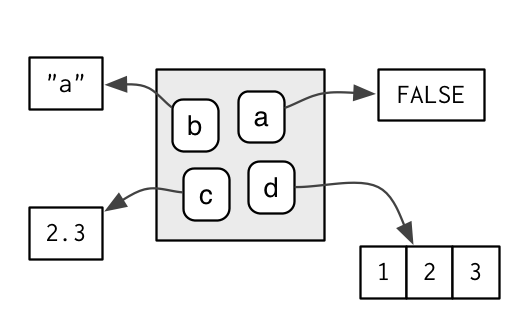

## Function Execution Environments

- Functions create new, short-lived environments called **execution environments**
  - object names usually passed into the execution environment
  - variables created in execution environments are not preserved
  - they exist only while the function is in progress

Functions have limited **scope**

## Function **Enclosing** Environments

An enclosing environment can be thought of as a function’s parent environment. It is where a function was created and where the function’s name is stored. Usually the *global* environment.

```r
y <- 1
f <- function(x) x + y
```

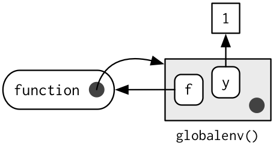

## Execution Environments

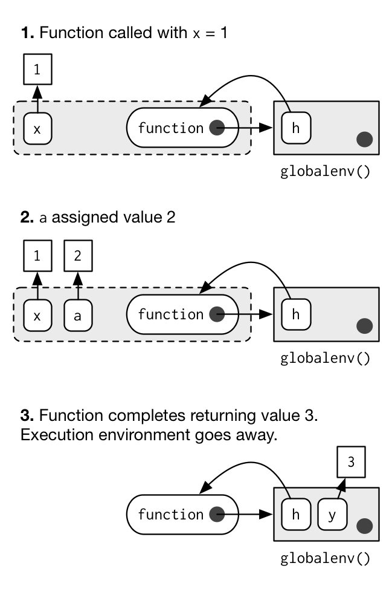

```r
h <- function(x=1) {
  a <- 2
  return(x + a)
}
y <- h(1)
```

- Function written, stored on memory, and linked to a name.
- *Execution* environment created with `y <- h(1)`
- `a` is assigned to value 2 within the execution environment
- Addition is performed, then stored as `y` within the *enclosing* environment.
- *Execution* environment dissapears.

## Short-lived execution environments

```r
system.time(add_five(1:10))
```

```
##    user  system elapsed
##       0       0       0
```

```r
system.time(add_five(1:10^8)) # 100 million values
```

```
##    user  system elapsed
##   0.145   0.088   0.287
```

## Debugging functions with `browser()`

- Because variables in the function environment disappear, it can be hard to find problems in functions
- `browser()` allows you to:
  - **pause execution** of the function
  - **access objects** within the function environment
  - **manipulate objects** within the function environment
  - *continue* OR *quit* function execution
- The location of `browser()` within the function matters

```r
add_five<-function(x=10){
  browser()
  y<-x+5
  return(y)
}
```

- (Go to Console)

## Other debugging tools

base R:

- `stopifnot()` - ensures data meets specific conditions before proceeding
- `debug()`
- `traceback()`

RStudio:

- an error inspector
- flag breakpoints in code

packages:

- `debug`

## Exercise 2 (Maybe a take home)

Write a function to calculate the species richness from each row of a community data matrix (e.g., `vegan::dune` or `vegan::varespec`). Richness is defined as simply the number of different species present at each site.

## Exercise 2: Calculating Species Richness

```r
library(vegan)
data(dune)
dune[1:5, 1:5]
```

```
##   Achimill Agrostol Airaprae Alopgeni Anthodor
## 1        1        0        0        0        0
## 2        3        0        0        2        0
## 3        0        4        0        7        0
## 4        0        8        0        2        0
## 5        2        0        0        0        4
```

## Exercise 2: Calculating Species Richness

```r
data(varespec)
varespec[1:5, 1:5]
```

```
##    Callvulg Empenigr Rhodtome Vaccmyrt Vaccviti
## 18     0.55    11.13     0.00     0.00    17.80
## 15     0.67     0.17     0.00     0.35    12.13
## 24     0.10     1.55     0.00     0.00    13.47
## 27     0.00    15.13     2.42     5.92    15.97
## 23     0.00    12.68     0.00     0.00    23.73
```

## Exercise 2: Calculating Species Richness

```r
rich<-function(comm){
  comm[comm > 0]<-1
  rowSums(comm)
}
rich(varespec)
```

```
## 18 15 24 27 23 19 22 16 28 13 14 20 25  7  5  6  3  4  2  9 12 10 11 21
## 29 26 23 25 26 28 27 27 27 31 25 27 30 26 23 24 25 26 19 27 18 24 23 28
```

## Exercise 2: Calculating Species Richness

```r
rich<-function(comm){
  apply(comm > 0, 1, sum)
}
rich(varespec)
```

```
## 18 15 24 27 23 19 22 16 28 13 14 20 25  7  5  6  3  4  2  9 12 10 11 21
## 29 26 23 25 26 28 27 27 27 31 25 27 30 26 23 24 25 26 19 27 18 24 23 28
```